# BIOS 611 HW3 Exploratory Analysis, tibbles, and data import (Chapters 7, 10, and 11.2)

Ty Darnell

09/12/2018

This homework is due `Monday September 17th by 6pm`.  
Both `.Rmd` and `.html` files should be submitted.  
(This set of exercise is mostly taken from R for Data Science by Garrett Grolemund and Hadley Wickham.)

# Exercise 1

1. Explore the distribution of `price`. Do you discover anything unusual or surprising? (Hint: Carefully think about the `binwidth` and make sure you try a wide range of values.)

   Answer: There are no diamonds with a price of $1500. Also a large amount of diamonds are priced around $750. This seems fairly cheap for a diamond so this is a little surprising.

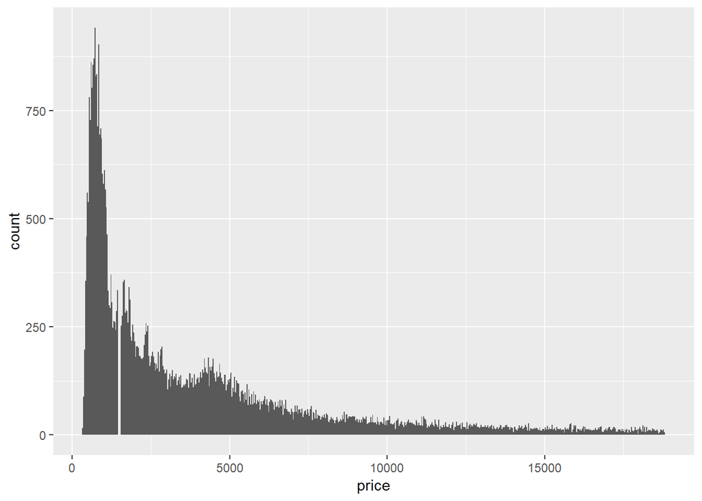

   ```r
   diamonds %>%
     ggplot(aes(x=price))+geom_histogram(binwidth=30)
   ```

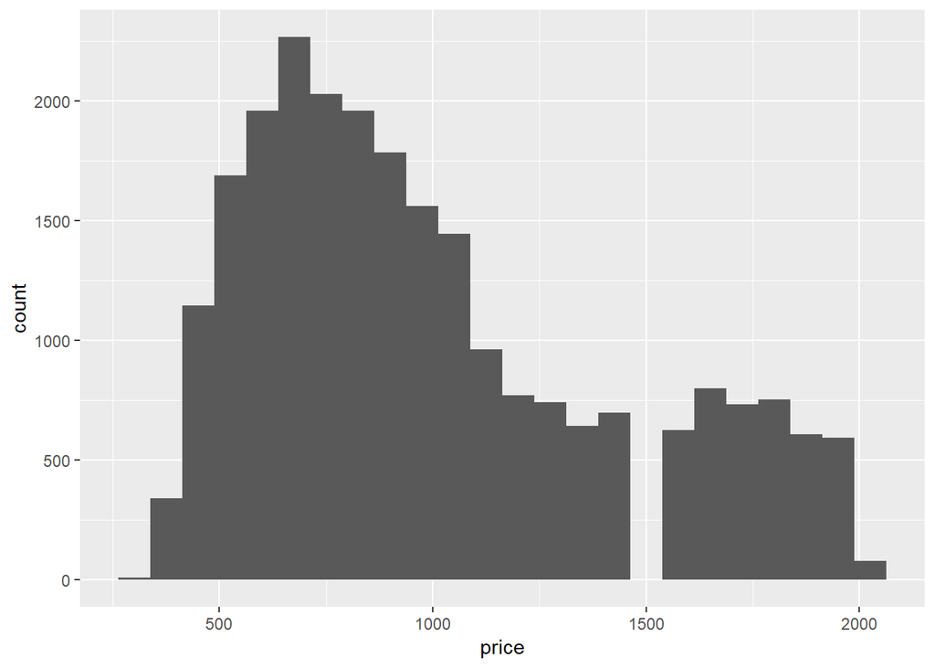

   ```r
   diamonds%>%filter(price<2000)%>%
      ggplot(aes(x=price))+geom_histogram(binwidth=75)
   ```

2. Compare and contrast `coord_cartesian()` vs `xlim()` or `ylim()` when zooming in on a histogram.

   Answer: ylim allows you to zoom in on different values of count and xlim allows you to zoom in on particular values of the distribution of the xvar.

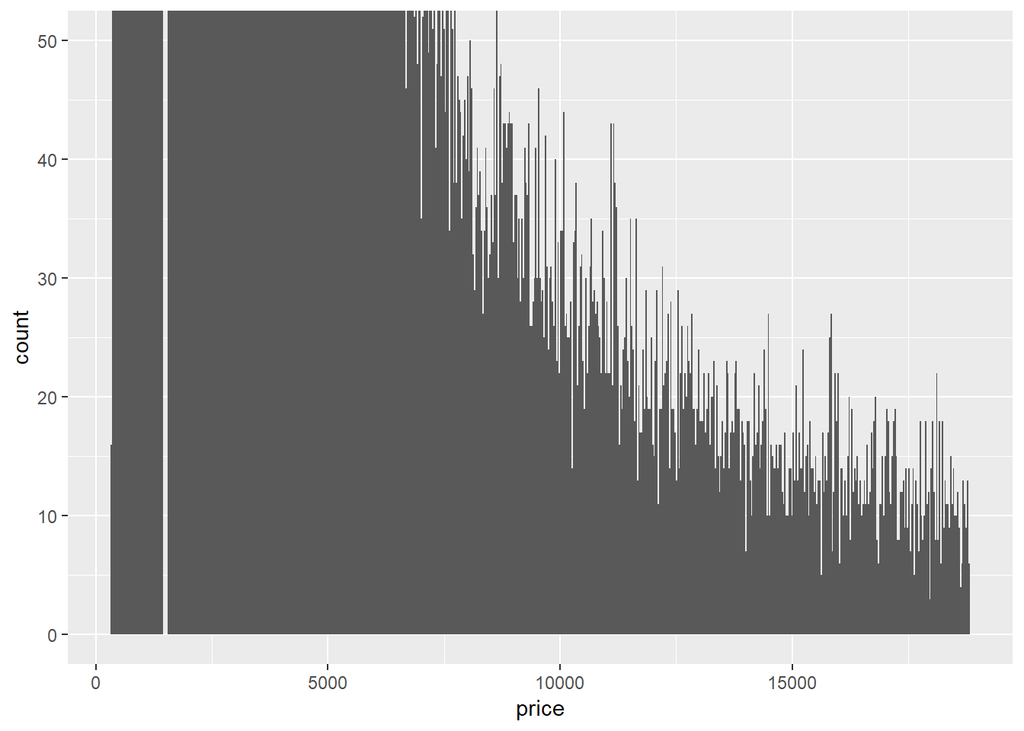

   ```r
   diamonds %>%
     ggplot(aes(x=price))+geom_histogram(binwidth=30)+coord_cartesian(ylim=c(0,50))
   ```

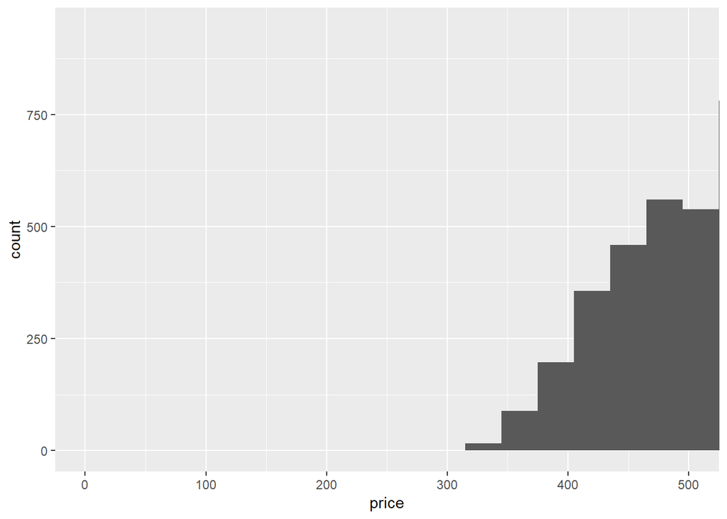

   ```r
   diamonds %>%
     ggplot(aes(x=price))+geom_histogram(binwidth=30)+coord_cartesian(xlim=c(0,500))
   ```

# Exercise 2

1. There are several ways of getting complete data (i.e. ignoring the incomplete cases). Using each of the following functions, try to get complete data.

   Answer:

   ```r
   # Use this dataset
   data.a = data.frame(no = 1:5, abc = letters[1:5], ABC = LETTERS[11:15], rand = rnorm(5))
   data.a[3,3] <- data.a[2,1] <- NA
   data.a
   ```

   ```
   ##   no abc  ABC        rand
   ## 1  1   a    K  0.64960781
   ## 2 NA   b    L -0.76126330
   ## 3  3   c <NA>  0.03129243
   ## 4  4   d    N -1.49479569
   ## 5  5   e    O -0.88895267
   ```

   ```r
   # A. na.omit
   na.omit(data.a)
   ```

   ```
   ##   no abc ABC       rand
   ## 1  1   a   K  0.6496078
   ## 4  4   d   N -1.4947957
   ## 5  5   e   O -0.8889527
   ```

   ```r
   # B. complete.cases
   data.a%>%filter(complete.cases(data.a))
   ```

   ```
   ##   no abc ABC       rand
   ## 1  1   a   K  0.6496078
   ## 2  4   d   N -1.4947957
   ## 3  5   e   O -0.8889527
   ```

2. What does `na.rm = TRUE` do in `mean()` and `sum()`?

   Answer: It removes the missing values for the summary statistic. If you take the mean or sum of something with na values it returns na unless na.rm=T is set.
3. We want to see if there is a pattern of delay according to the scheduled departure time. Criticize the following graph. (If you cannot notice the problem, go back to the example in the note and see why they used `mutate` function. Note only a small sample was used for convenience.)

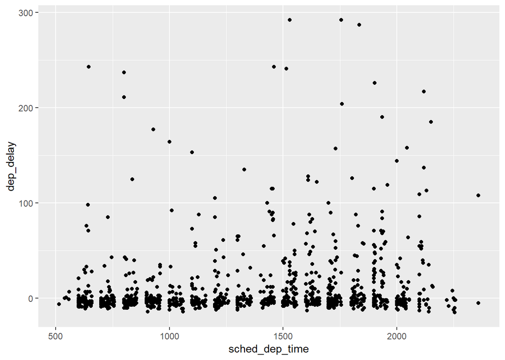

   ```r
   set.seed(1)
   newdata = sample_n(nycflights13::flights, 1000)
   newdata %>% ggplot(aes(sched_dep_time, dep_delay)) + geom_point()
   ```

   Answer: They did not create a variable for the cancelled flights. Since those are the na values, they are not taken into account. Because of this we do not see cancelled flights which could conceivably be related to the time of day.